# Movie Boxoffice Predictions 1

This is the first of the three notebooks that weare presenting, In this notebook we will be doing the inital cleaning of the data.

The data that we have recieved is very rich but as it was initially created for a recommender systems model is is not ideally fit to project box office. But as our group had our minds set on doing this we extracted as much meaningful information as possible from the text data and even scraped the web to find more data where needed. The web scraping code was written in python as we were more familar with that language but the rest of the data manipulation is shown in this R notebook. At the end of this we would like to have a solid dataset on which we can simply run our models.

Load the necessary libraries to run the code

`r`r library(tidyverse)

```
  method         from
  print.tbl_lazy
  print.tbl_sql
```

`r`r library(dplyr) library(readr) library(mice)

`r`r library(VIM)

```
VIM is ready to use.

Suggestions and bug-reports can be submitted at: https://github.com/statistikat/VIM/issues
```

### Read in the data

Load in the first set of data

`r`r meta_data <- read.csv(_metadata.csv, header = TRUE,na.strings=c(\)) head(meta_data)

|  | adult | belongs_to_collection | budget | genres | homepage | id | imdb_id | original_language | original_title | overview | popularity | poster_path | production_companies | production_countries | release_date | revenue | runtime | spoken_languages | status | tagline | title | video | vote_average | vote_count |
| --- | --- | --- | --- | --- | --- | --- | --- | --- | --- | --- | --- | --- | --- | --- | --- | --- | --- | --- | --- | --- | --- | --- | --- | --- |
| 1 | False | {'id': 10194, 'name': 'Toy Story Collection', 'poster_path': '/7G9915LfUQ2lVfwMEEhDsn3kT4B.jpg', 'backdrop_path': '/9FBwqcd9IRruEDUrTdcaafOMKUq.jpg'} | 30000000 | [{'id': 16, 'name': 'Animation'}, {'id': 35, 'name': 'Comedy'}, {'id': 10751, 'name': 'Family'}] | http://toystory.disney.com/toy-story | 862 | tt0114709 | en | Toy Story | Led by Woody, Andy's toys live happily in his room until Andy's birthday brings Buzz Lightyear onto the scene. Afraid of losing his place in Andy's heart, Woody plots against Buzz. But when circumstan… | 21.946943 | /rhIRbceoE9lR4veEXuwCC2wARtG.jpg | [{'name': 'Pixar Animation Studios', 'id': 3}] | [{'iso_3166_1': 'US', 'name': 'United States of America'}] | 1995-10-30 | 373554033 | 81 | [{'iso_639_1': 'en', 'name': 'English'}] | Released | NA | Toy Story | False | 7.7 | 5415 |
| 2 | False | NA | 65000000 | [{'id': 12, 'name': 'Adventure'}, {'id': 14, 'name': 'Fantasy'}, {'id': 10751, 'name': 'Family'}] | NA | 8844 | tt0113497 | en | Jumanji | When siblings Judy and Peter discover an enchanted board game that opens the door to a magical world, they unwittingly invite Alan -- an adult who's been trapped inside the game for 26 years -- into t… | 17.015539 | /vzmL6fP7aPKNKPRTFnZmiUfciyV.jpg | [{'name': 'TriStar Pictures', 'id': 559}, {'name': 'Teitler Film', 'id': 2550}, {'name': 'Interscope Communications', 'id': 10201}] | [{'iso_3166_1': 'US', 'name': 'United States of America'}] | 1995-12-15 | 262797249 | 104 | [{'iso_639_1': 'en', 'name': 'English'}, {'iso_639_1': 'fr', 'name': 'Français'}] | Released | Roll the dice and unleash the excitement! | Jumanji | False | 6.9 | 2413 |
| 3 | False | {'id': 119050, 'name': 'Grumpy Old Men Collection', 'poster_path': '/nLvUdqgPgm3F85NMCii9gVFUcet.jpg', 'backdrop_path': '/hypTnLot2z8wpFS7qwsQHW1uV8u.jpg'} | 0 | [{'id': 10749, 'name': 'Romance'}, {'id': 35, 'name': 'Comedy'}] | NA | 15602 | tt0113228 | en | Grumpier Old Men | A family wedding reignites the ancient feud between next-door neighbors and fishing buddies John and Max. Meanwhile, a sultry Italian divorcée opens a restaurant at the local bait shop, alarming the … | 11.7129 | /6ksm1sjKMFLbO7UY2i6G1ju9SML.jpg | [{'name': 'Warner Bros.', 'id': 6194}, {'name': 'Lancaster Gate', 'id': 19464}] | [{'iso_3166_1': 'US', 'name': 'United States of America'}] | 1995-12-22 | 0 | 101 | [{'iso_639_1': 'en', 'name': 'English'}] | Released | Still Yelling. Still Fighting. Still Ready for Love. | Grumpier Old Men | False | 6.5 | 92 |
| 4 | False | NA | 16000000 | [{'id': 35, 'name': 'Comedy'}, {'id': 18, 'name': 'Drama'}, {'id': 10749, 'name': 'Romance'}] | NA | 31357 | tt0114885 | en | Waiting to Exhale | Cheated on, mistreated and stepped on, the women are holding their breath, waiting for the elusive "good man" to break a string of less-than-stellar lovers. Friends and confidants Vannah, Bernie, Glo … | 3.859495 | /16XOMpEaLWkrcPqSQqhTmeJuqQl.jpg | [{'name': 'Twentieth Century Fox Film Corporation', 'id': 306}] | [{'iso_3166_1': 'US', 'name': 'United States of America'}] | 1995-12-22 | 81452156 | 127 | [{'iso_639_1': 'en', 'name': 'English'}] | Released | Friends are the people who let you be yourself... and never let you forget it. | Waiting to Exhale | False | 6.1 | 34 |
| 5 | False | {'id': 96871, 'name': 'Father of the Bride Collection', 'poster_path': '/nts4iOmNnq7GNicycMJ9pSAn204.jpg', 'backdrop_path': '/7qwE57OVZmMJChBpLEbJEmzUydk.jpg'} | 0 | [{'id': 35, 'name': 'Comedy'}] | NA | 11862 | tt0113041 | en | Father of the Bride Part II | Just when George Banks has recovered from his daughter's wedding, he receives the news that she's pregnant ... and that George's wife, Nina, is expecting too. He was planning on selling their home, bu… | 8.387519 | /e64sOI48hQXyru7naBFyssKFxVd.jpg | [{'name': 'Sandollar Productions', 'id': 5842}, {'name': 'Touchstone Pictures', 'id': 9195}] | [{'iso_3166_1': 'US', 'name': 'United States of America'}] | 1995-02-10 | 76578911 | 106 | [{'iso_639_1': 'en', 'name': 'English'}] | Released | Just When His World Is Back To Normal... He's In For The Surprise Of His Life! | Father of the Bride Part II | False | 5.7 | 173 |
| 6 | False | NA | 60000000 | [{'id': 28, 'name': 'Action'}, {'id': 80, 'name': 'Crime'}, {'id': 18, 'name': 'Drama'}, {'id': 53, 'name': 'Thriller'}] | NA | 949 | tt0113277 | en | Heat | Obsessive master thief, Neil McCauley leads a top-notch crew on various insane heists throughout Los Angeles while a mentally unstable detective, Vincent Hanna pursues him without rest. Each man recog… | 17.924927 | /zMyfPUelumio3tiDKPffaUpsQTD.jpg | [{'name': 'Regency Enterprises', 'id': 508}, {'name': 'Forward Pass', 'id': 675}, {'name': 'Warner Bros.', 'id': 6194}] | [{'iso_3166_1': 'US', 'name': 'United States of America'}] | 1995-12-15 | 187436818 | 170 | [{'iso_639_1': 'en', 'name': 'English'}, {'iso_639_1': 'es', 'name': 'Español'}] | Released | A Los Angeles Crime Saga | Heat | False | 7.7 | 1886 |

Get summary statistics on the data

`r`r summary(meta_data)

```
    adult           belongs_to_collection    budget             genres            homepage
 Length:45466       Length:45466          Length:45466       Length:45466       Length:45466
 Class :character   Class :character      Class :character   Class :character   Class :character
 Mode  :character   Mode  :character      Mode  :character   Mode  :character   Mode  :character




      id              imdb_id          original_language  original_title       overview
 Length:45466       Length:45466       Length:45466       Length:45466       Length:45466
 Class :character   Class :character   Class :character   Class :character   Class :character
 Mode  :character   Mode  :character   Mode  :character   Mode  :character   Mode  :character




  popularity        poster_path        production_companies production_countries release_date
 Length:45466       Length:45466       Length:45466         Length:45466         Length:45466
 Class :character   Class :character   Class :character     Class :character     Class :character
 Mode  :character   Mode  :character   Mode  :character     Mode  :character     Mode  :character




    revenue             runtime        spoken_languages      status            tagline
 Min.   :0.000e+00   Min.   :   0.00   Length:45466       Length:45466       Length:45466
 1st Qu.:0.000e+00   1st Qu.:  85.00   Class :character   Class :character   Class :character
 Median :0.000e+00   Median :  95.00   Mode  :character   Mode  :character   Mode  :character
 Mean   :1.121e+07   Mean   :  94.13
 3rd Qu.:0.000e+00   3rd Qu.: 107.00
 Max.   :2.788e+09   Max.   :1256.00
 NA's   :6           NA's   :263
    title              video            vote_average      vote_count
 Length:45466       Length:45466       Min.   : 0.000   Min.   :    0.0
 Class :character   Class :character   1st Qu.: 5.000   1st Qu.:    3.0
 Mode  :character   Mode  :character   Median : 6.000   Median :   10.0
                                       Mean   : 5.618   Mean   :  109.9
                                       3rd Qu.: 6.800   3rd Qu.:   34.0
                                       Max.   :10.000   Max.   :14075.0
                                       NA's   :6        NA's   :6
```

Because there were a lot of NAs/0 for Total Revenue and that is what we were trying to predict so we decided to scrape the web using a python script. We will merge in the two data sets that we collected

`r`r movie_revenue <- read.csv(_revenue.csv, header = TRUE,na.strings=c(\)) ratings <- read.csv(.csv, header = TRUE,na.strings=c(\)) credits <- read.csv(.csv, header = TRUE, na.strings = c(\))

meta_data$id <- as.character(meta_data$id) data <- left_join(meta_data, ratings, by = ‘id’) data <- left_join(data, movie_revenue, by = c(_id = .ID)) credits$id <- as.character(credits$id) data <- left_join(data, credits, by = ‘id’)

head(data)

|  | adult | belongs_to_collection | budget | genres | homepage | id | imdb_id | original_language | original_title | overview | popularity | poster_path | production_companies | production_countries | release_date | revenue | runtime | spoken_languages | status | tagline | title | video | vote_average | vote_count | orginal_title_2 | year_2 | meterScore | meterClass | Total.Revenue | … |
| --- | --- | --- | --- | --- | --- | --- | --- | --- | --- | --- | --- | --- | --- | --- | --- | --- | --- | --- | --- | --- | --- | --- | --- | --- | --- | --- | --- | --- | --- | --- |
| 1 | False | {'id': 10194, 'name': 'Toy Story Collection', 'poster_path': '/7G9915LfUQ2lVfwMEEhDsn3kT4B.jpg', 'backdrop_path': '/9FBwqcd9IRruEDUrTdcaafOMKUq.jpg'} | 30000000 | [{'id': 16, 'name': 'Animation'}, {'id': 35, 'name': 'Comedy'}, {'id': 10751, 'name': 'Family'}] | http://toystory.disney.com/toy-story | 862 | tt0114709 | en | Toy Story | Led by Woody, Andy's toys live happily in his room until Andy's birthday brings Buzz Lightyear onto the scene. Afraid of losing his place in Andy's heart, Woody plots against Buzz. But when circumstan… | 21.946943 | /rhIRbceoE9lR4veEXuwCC2wARtG.jpg | [{'name': 'Pixar Animation Studios', 'id': 3}] | [{'iso_3166_1': 'US', 'name': 'United States of America'}] | 1995-10-30 | 373554033 | 81 | [{'iso_639_1': 'en', 'name': 'English'}] | Released | NA | Toy Story | False | 7.7 | 5415 | Toy Story | 1995 | 100 | certified_fresh | $404,265,656 | … |
| 2 | False | NA | 65000000 | [{'id': 12, 'name': 'Adventure'}, {'id': 14, 'name': 'Fantasy'}, {'id': 10751, 'name': 'Family'}] | NA | 8844 | tt0113497 | en | Jumanji | When siblings Judy and Peter discover an enchanted board game that opens the door to a magical world, they unwittingly invite Alan -- an adult who's been trapped inside the game for 26 years -- into t… | 17.015539 | /vzmL6fP7aPKNKPRTFnZmiUfciyV.jpg | [{'name': 'TriStar Pictures', 'id': 559}, {'name': 'Teitler Film', 'id': 2550}, {'name': 'Interscope Communications', 'id': 10201}] | [{'iso_3166_1': 'US', 'name': 'United States of America'}] | 1995-12-15 | 262797249 | 104 | [{'iso_639_1': 'en', 'name': 'English'}, {'iso_639_1': 'fr', 'name': 'Français'}] | Released | Roll the dice and unleash the excitement! | Jumanji | False | 6.9 | 2413 | Jumanji | 1995 | 55 | rotten | $262,821,940 | … |
| 3 | False | {'id': 119050, 'name': 'Grumpy Old Men Collection', 'poster_path': '/nLvUdqgPgm3F85NMCii9gVFUcet.jpg', 'backdrop_path': '/hypTnLot2z8wpFS7qwsQHW1uV8u.jpg'} | 0 | [{'id': 10749, 'name': 'Romance'}, {'id': 35, 'name': 'Comedy'}] | NA | 15602 | tt0113228 | en | Grumpier Old Men | A family wedding reignites the ancient feud between next-door neighbors and fishing buddies John and Max. Meanwhile, a sultry Italian divorcée opens a restaurant at the local bait shop, alarming the … | 11.7129 | /6ksm1sjKMFLbO7UY2i6G1ju9SML.jpg | [{'name': 'Warner Bros.', 'id': 6194}, {'name': 'Lancaster Gate', 'id': 19464}] | [{'iso_3166_1': 'US', 'name': 'United States of America'}] | 1995-12-22 | 0 | 101 | [{'iso_639_1': 'en', 'name': 'English'}] | Released | Still Yelling. Still Fighting. Still Ready for Love. | Grumpier Old Men | False | 6.5 | 92 | Grumpier Old Men | 1995 | 17 | rotten | $71,518,503 | … |
| 4 | False | NA | 16000000 | [{'id': 35, 'name': 'Comedy'}, {'id': 18, 'name': 'Drama'}, {'id': 10749, 'name': 'Romance'}] | NA | 31357 | tt0114885 | en | Waiting to Exhale | Cheated on, mistreated and stepped on, the women are holding their breath, waiting for the elusive "good man" to break a string of less-than-stellar lovers. Friends and confidants Vannah, Bernie, Glo … | 3.859495 | /16XOMpEaLWkrcPqSQqhTmeJuqQl.jpg | [{'name': 'Twentieth Century Fox Film Corporation', 'id': 306}] | [{'iso_3166_1': 'US', 'name': 'United States of America'}] | 1995-12-22 | 81452156 | 127 | [{'iso_639_1': 'en', 'name': 'English'}] | Released | Friends are the people who let you be yourself... and never let you forget it. | Waiting to Exhale | False | 6.1 | 34 | Waiting to Exhale | 1995 | 56 | rotten | $81,452,156 | … |
| 5 | False | {'id': 96871, 'name': 'Father of the Bride Collection', 'poster_path': '/nts4iOmNnq7GNicycMJ9pSAn204.jpg', 'backdrop_path': '/7qwE57OVZmMJChBpLEbJEmzUydk.jpg'} | 0 | [{'id': 35, 'name': 'Comedy'}] | NA | 11862 | tt0113041 | en | Father of the Bride Part II | Just when George Banks has recovered from his daughter's wedding, he receives the news that she's pregnant ... and that George's wife, Nina, is expecting too. He was planning on selling their home, bu… | 8.387519 | /e64sOI48hQXyru7naBFyssKFxVd.jpg | [{'name': 'Sandollar Productions', 'id': 5842}, {'name': 'Touchstone Pictures', 'id': 9195}] | [{'iso_3166_1': 'US', 'name': 'United States of America'}] | 1995-02-10 | 76578911 | 106 | [{'iso_639_1': 'en', 'name': 'English'}] | Released | Just When His World Is Back To Normal... He's In For The Surprise Of His Life! | Father of the Bride Part II | False | 5.7 | 173 | Father of the Bride Part II | 1995 | 48 | rotten | $76,594,107 | … |
| 6 | False | NA | 60000000 | [{'id': 28, 'name': 'Action'}, {'id': 80, 'name': 'Crime'}, {'id': 18, 'name': 'Drama'}, {'id': 53, 'name': 'Thriller'}] | NA | 949 | tt0113277 | en | Heat | Obsessive master thief, Neil McCauley leads a top-notch crew on various insane heists throughout Los Angeles while a mentally unstable detective, Vincent Hanna pursues him without rest. Each man recog… | 17.924927 | /zMyfPUelumio3tiDKPffaUpsQTD.jpg | [{'name': 'Regency Enterprises', 'id': 508}, {'name': 'Forward Pass', 'id': 675}, {'name': 'Warner Bros.', 'id': 6194}] | [{'iso_3166_1': 'US', 'name': 'United States of America'}] | 1995-12-15 | 187436818 | 170 | [{'iso_639_1': 'en', 'name': 'English'}, {'iso_639_1': 'es', 'name': 'Español'}] | Released | A Los Angeles Crime Saga | Heat | False | 7.7 | 1886 | Heat | 1995 | 87 | certified_fresh | $187,436,818 | … |

`r`r summary(data)

```
    adult           belongs_to_collection    budget             genres            homepage
 Length:46271       Length:46271          Length:46271       Length:46271       Length:46271
 Class :character   Class :character      Class :character   Class :character   Class :character
 Mode  :character   Mode  :character      Mode  :character   Mode  :character   Mode  :character




      id              imdb_id          original_language  original_title       overview
 Length:46271       Length:46271       Length:46271       Length:46271       Length:46271
 Class :character   Class :character   Class :character   Class :character   Class :character
 Mode  :character   Mode  :character   Mode  :character   Mode  :character   Mode  :character




  popularity        poster_path        production_companies production_countries release_date
 Length:46271       Length:46271       Length:46271         Length:46271         Length:46271
 Class :character   Class :character   Class :character     Class :character     Class :character
 Mode  :character   Mode  :character   Mode  :character     Mode  :character     Mode  :character




    revenue             runtime        spoken_languages      status            tagline
 Min.   :0.000e+00   Min.   :   0.00   Length:46271       Length:46271       Length:46271
 1st Qu.:0.000e+00   1st Qu.:  85.00   Class :character   Class :character   Class :character
 Median :0.000e+00   Median :  95.00   Mode  :character   Mode  :character   Mode  :character
 Mean   :1.107e+07   Mean   :  94.04
 3rd Qu.:0.000e+00   3rd Qu.: 107.00
 Max.   :2.788e+09   Max.   :1256.00
 NA's   :12          NA's   :307
    title              video            vote_average      vote_count      orginal_title_2
 Length:46271       Length:46271       Min.   : 0.000   Min.   :    0.0   Length:46271
 Class :character   Class :character   1st Qu.: 5.000   1st Qu.:    3.0   Class :character
 Mode  :character   Mode  :character   Median : 6.000   Median :   10.0   Mode  :character
                                       Mean   : 5.607   Mean   :  108.5
                                       3rd Qu.: 6.800   3rd Qu.:   34.0
                                       Max.   :10.000   Max.   :14075.0
                                       NA's   :12       NA's   :12
    year_2            meterScore      meterClass        Total.Revenue          cast
 Length:46271       Min.   : -2.00   Length:46271       Length:46271       Length:46271
 Class :character   1st Qu.: -2.00   Class :character   Class :character   Class :character
 Mode  :character   Median : -1.00   Mode  :character   Mode  :character   Mode  :character
                    Mean   : 17.32
                    3rd Qu.: 27.00
                    Max.   :100.00
                    NA's   :502
     crew
 Length:46271
 Class :character
 Mode  :character
```

Subsitutude values that mean no value to NA (empty strings already converted to NA)

`r`r #Sometimes the csv files read in the data types differently so just to make sure everyone has the same data types I will convert everything to character if its a factor

data <- mutate_if(data, is.factor, as.character())

#0 dollar budget likely indicates NA as 35k of them have 0 budget data$budget[data$budget == \0] <- NA

#0 total.revenue indicates NA data$Total.Revenue[data$Total.Revenue == \0] <- NA

#if vote_count[i] = 0, set vote_count[i] = NA and set vote_average[i] = NA data$vote_count[data$vote_count == \0] <- NA data$vote_average[is.na(data$vote_count)] <- NA

#for meterScore and meterClass if the values are <0 then they are NA data$meterScore[data$meterScore < 0] <- NA data$meterClass[data$meterClass < 0] <- NA summary(data)

```
    adult           belongs_to_collection    budget             genres            homepage
 Length:46271       Length:46271          Length:46271       Length:46271       Length:46271
 Class :character   Class :character      Class :character   Class :character   Class :character
 Mode  :character   Mode  :character      Mode  :character   Mode  :character   Mode  :character




      id              imdb_id          original_language  original_title       overview
 Length:46271       Length:46271       Length:46271       Length:46271       Length:46271
 Class :character   Class :character   Class :character   Class :character   Class :character
 Mode  :character   Mode  :character   Mode  :character   Mode  :character   Mode  :character




  popularity        poster_path        production_companies production_countries release_date
 Length:46271       Length:46271       Length:46271         Length:46271         Length:46271
 Class :character   Class :character   Class :character     Class :character     Class :character
 Mode  :character   Mode  :character   Mode  :character     Mode  :character     Mode  :character




    revenue             runtime        spoken_languages      status            tagline
 Min.   :0.000e+00   Min.   :   0.00   Length:46271       Length:46271       Length:46271
 1st Qu.:0.000e+00   1st Qu.:  85.00   Class :character   Class :character   Class :character
 Median :0.000e+00   Median :  95.00   Mode  :character   Mode  :character   Mode  :character
 Mean   :1.107e+07   Mean   :  94.04
 3rd Qu.:0.000e+00   3rd Qu.: 107.00
 Max.   :2.788e+09   Max.   :1256.00
 NA's   :12          NA's   :307
    title              video            vote_average      vote_count      orginal_title_2
 Length:46271       Length:46271       Min.   : 0.000   Min.   :    1.0   Length:46271
 Class :character   Class :character   1st Qu.: 5.300   1st Qu.:    4.0   Class :character
 Mode  :character   Mode  :character   Median : 6.100   Median :   11.0   Mode  :character
                                       Mean   : 6.004   Mean   :  116.2
                                       3rd Qu.: 6.800   3rd Qu.:   38.0
                                       Max.   :10.000   Max.   :14075.0
                                       NA's   :3068     NA's   :3068
    year_2            meterScore      meterClass        Total.Revenue          cast
 Length:46271       Min.   :  0.00   Length:46271       Length:46271       Length:46271
 Class :character   1st Qu.: 38.00   Class :character   Class :character   Class :character
 Mode  :character   Median : 67.00   Mode  :character   Mode  :character   Mode  :character
                    Mean   : 61.04
                    3rd Qu.: 86.00
                    Max.   :100.00
                    NA's   :32543
     crew
 Length:46271
 Class :character
 Mode  :character
```

### First set of Data Cleaning

There is a lot that needs to happen to the data before we are able to any analysis

The first thing that we need to do is remove the variables that have no impact and/or is something that we cannot analyze. These variables include:

1. homepage: URL to homepage, has no value
2. id: rotten tomatoes id, has no value as each id is unique
3. imdb_id: imdb id, has no value as each id is unique
4. overview: long description of the movie, hard to analyze
5. poster_path: URL to poster, has no value
6. revenue: this revenue has a lot of incomplete values, so new revenue data was scrapped from the web
7. status: vast majority are released
8. video: only 23 out of 46K of them are true, and we dont know what this variable is, so no need to analyze it
9. original_title: there is a title variable, similar variables same in majority of the cases
10. orginal_title_2: Same as original_title variable
11. year_2: There is a release date variable which is easier to work with and gives the same value

`r`r data = subset(data, select = -c(homepage, id, imdb_id, overview, poster_path, revenue, status, video, original_title, orginal_title_2, year_2))

`r`r head(data)

|  | adult | belongs_to_collection | budget | genres | original_language | popularity | production_companies | production_countries | release_date | runtime | spoken_languages | tagline | title | vote_average | vote_count | meterScore | meterClass | Total.Revenue | cast | crew |
| --- | --- | --- | --- | --- | --- | --- | --- | --- | --- | --- | --- | --- | --- | --- | --- | --- | --- | --- | --- | --- |
| 1 | False | {'id': 10194, 'name': 'Toy Story Collection', 'poster_path': '/7G9915LfUQ2lVfwMEEhDsn3kT4B.jpg', 'backdrop_path': '/9FBwqcd9IRruEDUrTdcaafOMKUq.jpg'} | 30000000 | [{'id': 16, 'name': 'Animation'}, {'id': 35, 'name': 'Comedy'}, {'id': 10751, 'name': 'Family'}] | en | 21.946943 | [{'name': 'Pixar Animation Studios', 'id': 3}] | [{'iso_3166_1': 'US', 'name': 'United States of America'}] | 1995-10-30 | 81 | [{'iso_639_1': 'en', 'name': 'English'}] | NA | Toy Story | 7.7 | 5415 | 100 | certified_fresh | $404,265,656 | [{'cast_id': 14, 'character': 'Woody (voice)', 'credit_id': '52fe4284c3a36847f8024f95', 'gender': 2, 'id': 31, 'name': 'Tom Hanks', 'order': 0, 'profile_path': '/pQFoyx7rp09CJTAb932F2g8Nlho.jpg'}, {'c… | [{'credit_id': '52fe4284c3a36847f8024f49', 'department': 'Directing', 'gender': 2, 'id': 7879, 'job': 'Director', 'name': 'John Lasseter', 'profile_path': '/7EdqiNbr4FRjIhKHyPPdFfEEEFG.jpg'}, {'credit… |
| 2 | False | NA | 65000000 | [{'id': 12, 'name': 'Adventure'}, {'id': 14, 'name': 'Fantasy'}, {'id': 10751, 'name': 'Family'}] | en | 17.015539 | [{'name': 'TriStar Pictures', 'id': 559}, {'name': 'Teitler Film', 'id': 2550}, {'name': 'Interscope Communications', 'id': 10201}] | [{'iso_3166_1': 'US', 'name': 'United States of America'}] | 1995-12-15 | 104 | [{'iso_639_1': 'en', 'name': 'English'}, {'iso_639_1': 'fr', 'name': 'Français'}] | Roll the dice and unleash the excitement! | Jumanji | 6.9 | 2413 | 55 | rotten | $262,821,940 | [{'cast_id': 1, 'character': 'Alan Parrish', 'credit_id': '52fe44bfc3a36847f80a7c73', 'gender': 2, 'id': 2157, 'name': 'Robin Williams', 'order': 0, 'profile_path': '/sojtJyIV3lkUeThD7A2oHNm8183.jpg'}… | [{'credit_id': '52fe44bfc3a36847f80a7cd1', 'department': 'Production', 'gender': 2, 'id': 511, 'job': 'Executive Producer', 'name': 'Larry J. Franco', 'profile_path': None}, {'credit_id': '52fe44bfc3a… |
| 3 | False | {'id': 119050, 'name': 'Grumpy Old Men Collection', 'poster_path': '/nLvUdqgPgm3F85NMCii9gVFUcet.jpg', 'backdrop_path': '/hypTnLot2z8wpFS7qwsQHW1uV8u.jpg'} | NA | [{'id': 10749, 'name': 'Romance'}, {'id': 35, 'name': 'Comedy'}] | en | 11.7129 | [{'name': 'Warner Bros.', 'id': 6194}, {'name': 'Lancaster Gate', 'id': 19464}] | [{'iso_3166_1': 'US', 'name': 'United States of America'}] | 1995-12-22 | 101 | [{'iso_639_1': 'en', 'name': 'English'}] | Still Yelling. Still Fighting. Still Ready for Love. | Grumpier Old Men | 6.5 | 92 | 17 | rotten | $71,518,503 | [{'cast_id': 2, 'character': 'Max Goldman', 'credit_id': '52fe466a9251416c75077a8d', 'gender': 2, 'id': 6837, 'name': 'Walter Matthau', 'order': 0, 'profile_path': '/xJVkvprOnzP5Zdh5y63y8HHniDZ.jpg'},… | [{'credit_id': '52fe466a9251416c75077a89', 'department': 'Directing', 'gender': 2, 'id': 26502, 'job': 'Director', 'name': 'Howard Deutch', 'profile_path': '/68Vae1HkU1NxQZ6KEmuxIpno7c9.jpg'}, {'credi… |
| 4 | False | NA | 16000000 | [{'id': 35, 'name': 'Comedy'}, {'id': 18, 'name': 'Drama'}, {'id': 10749, 'name': 'Romance'}] | en | 3.859495 | [{'name': 'Twentieth Century Fox Film Corporation', 'id': 306}] | [{'iso_3166_1': 'US', 'name': 'United States of America'}] | 1995-12-22 | 127 | [{'iso_639_1': 'en', 'name': 'English'}] | Friends are the people who let you be yourself... and never let you forget it. | Waiting to Exhale | 6.1 | 34 | 56 | rotten | $81,452,156 | [{'cast_id': 1, 'character': "Savannah 'Vannah' Jackson", 'credit_id': '52fe44779251416c91011aad', 'gender': 1, 'id': 8851, 'name': 'Whitney Houston', 'order': 0, 'profile_path': '/69ouDnXnmklYPr4sMJX… | [{'credit_id': '52fe44779251416c91011acb', 'department': 'Directing', 'gender': 2, 'id': 2178, 'job': 'Director', 'name': 'Forest Whitaker', 'profile_path': '/4pMQkelS5lK661m9Kz3oIxLYiyS.jpg'}, {'cred… |
| 5 | False | {'id': 96871, 'name': 'Father of the Bride Collection', 'poster_path': '/nts4iOmNnq7GNicycMJ9pSAn204.jpg', 'backdrop_path': '/7qwE57OVZmMJChBpLEbJEmzUydk.jpg'} | NA | [{'id': 35, 'name': 'Comedy'}] | en | 8.387519 | [{'name': 'Sandollar Productions', 'id': 5842}, {'name': 'Touchstone Pictures', 'id': 9195}] | [{'iso_3166_1': 'US', 'name': 'United States of America'}] | 1995-02-10 | 106 | [{'iso_639_1': 'en', 'name': 'English'}] | Just When His World Is Back To Normal... He's In For The Surprise Of His Life! | Father of the Bride Part II | 5.7 | 173 | 48 | rotten | $76,594,107 | [{'cast_id': 1, 'character': 'George Banks', 'credit_id': '52fe44959251416c75039eb9', 'gender': 2, 'id': 67773, 'name': 'Steve Martin', 'order': 0, 'profile_path': '/rI2EMvkfKKPKa5z0nM2pFVBtUyO.jpg'},… | [{'credit_id': '52fe44959251416c75039ed7', 'department': 'Sound', 'gender': 2, 'id': 37, 'job': 'Original Music Composer', 'name': 'Alan Silvestri', 'profile_path': '/chEsfnDEtRmv1bfOaNAoVEzhCc6.jpg'}… |
| 6 | False | NA | 60000000 | [{'id': 28, 'name': 'Action'}, {'id': 80, 'name': 'Crime'}, {'id': 18, 'name': 'Drama'}, {'id': 53, 'name': 'Thriller'}] | en | 17.924927 | [{'name': 'Regency Enterprises', 'id': 508}, {'name': 'Forward Pass', 'id': 675}, {'name': 'Warner Bros.', 'id': 6194}] | [{'iso_3166_1': 'US', 'name': 'United States of America'}] | 1995-12-15 | 170 | [{'iso_639_1': 'en', 'name': 'English'}, {'iso_639_1': 'es', 'name': 'Español'}] | A Los Angeles Crime Saga | Heat | 7.7 | 1886 | 87 | certified_fresh | $187,436,818 | [{'cast_id': 25, 'character': 'Lt. Vincent Hanna', 'credit_id': '52fe4292c3a36847f80291f5', 'gender': 2, 'id': 1158, 'name': 'Al Pacino', 'order': 0, 'profile_path': '/ks7Ba8x9fJUlP9decBr6Dh5mThX.jpg'… | [{'credit_id': '52fe4292c3a36847f802916d', 'department': 'Directing', 'gender': 2, 'id': 638, 'job': 'Director', 'name': 'Michael Mann', 'profile_path': '/nKmUpRpuQIsYubR7vIxVKhkbaTW.jpg'}, {'credit_i… |

### Data Cleaning and Manipulation

Changes to be made to the data based on the columns:

1. adult: change type to factor
2. belongs_to_collection: needs to made a dummy variable (TRUE or FALSE), we cannot analyze based on collection it belongs to as majority do not belong to a collection, and you cannot add any value there otherwise the model will think everything not part of a collection belongs to the same collection, after converting to dummy variable change type to factor
3. budget: change type to numeric
4. genres: create 20 dummy variables subset of genres the movie is, extract the genres from the list, after that convert each variable to a factor
5. original_language: change type to factor
6. popularity: change type to numeric
7. production_companies: Find the top 10 companies and create 10 dummy variables, we do this as there are generally multiple production companies that work on the same movie. so we can have multiple variables with a value of true. Convert each type dummy vairable to a factor
8. production_countries: extract the first country (main country the movie was produced), and change type to factor, create a new variable called num_production_countries that counts the number of production countries, as the factor variable country cannot have more than 53 different categories, if it is one of the smaller countries (not top 31), it will go in the other category, the reason we choose top 31 is because that is the cutoff where that country has at least 100 movies made in that country
9. release_date: change type to date
10. runtime: change type to numeric
11. spoken_languages: count the number of spoken languages in the movie, change type to numeric
12. title: nothing to change, we should probably drop this variable as it is a text, and we do not do any text mining to it
13. vote_average: No change
14. vote_count: No change
15. meterScore: No change
16. meterClass: change to type factor
17. Total.Revenue: remove $, change type to numeric
18. cast: introduce new variables for the number of cast members, female cast members, male cast members, and unspecified cast members
19. crew: similar to cast, introduce new variables for the number of crew members, female crew members, male crew members, and unspecified crew members

#### Type Changes

`r`r # deal with variables that only require a type change first, simplest change to make data$adult <- as.factor(data$adult) data$original_language <- as.factor(data$original_language) data$budget <- as.numeric(data$budget)

```
NAs introduced by coercion
```

`r`r data$popularity <- as.numeric(data$popularity)

```
NAs introduced by coercion
```

`r`r data$release_date <- as.Date(data$release_date) data$runtime <- as.numeric(data$runtime) data$meterClass <- as.factor(data$meterClass)

#### Simple Extraction from the data

The reason that we have to extract from the data is because these columns are text data so we need to extract meaning our of it.

1. For the collection data it would tell us what collection the data bellonged to and that is difficult to analyze so rather we added a column called is_in_collection which is a TRUE or FALSE column (categorical) which is something the random forest model can analyze easily. We could have potentially just created categories for each collections but that was more than 53 levels to a factor variable so we could not do that
2. For the spoken_languages it gave us a list of languages so we just extracted the number
3. Similar to collection we did a true and false for tagline as many movies did not have a tagline
4. For the Total.Revenue we just had to remove the $ and extract the number
5. For cast and crew we were given a list of each member along with their gender so we extracted the number of each (total cast/crew, male cast/crew, female cast/crew and unspecified cast/crew)

`r`r # Changes

#belongs_to_collection CHANGES # Change all NAs to FALSE in the belongs_to_collection data$is_in_collection[is.na(data$belongs_to_collection)] <- FALSE #If it does not belong to a collection then it is does, so if it is not false then set the value to true data$is_in_collection[!(is.na(data$belongs_to_collection))] <- TRUE data$is_in_collection <- as.factor(data$is_in_collection)

#spoken_languages CHANGES data$num_spoken_languages <- str_count(data$spoken_languages, ‘name’)

#tagline CHANGES data$has_tagline[is.na(data$tagline)] <- FALSE data$has_tagline[data$tagline != FALSE] <- TRUE data$has_tagline <- as.factor(data$has_tagline)

#### Genre Variables Being Created

For the genres we were given a list of genres and there were genreally 3-4 genres. So we had two options we could either extract 1 genres (likely the first one) and call that the main genre with just one variable or we could create 20 variables (one for each genre) and say TRUE and FALSE for each one. We decided it could be beneficial to look at each genre and so we created 20 variables

`r`r #genres CHANGES #to create the dummy variables we will go through each row and update the dummy variables accordingly

#create the dummy variable rows and set it all to FALSE data$comedy <- FALSE data$horror <- FALSE data$action <- FALSE data$drama <- FALSE data$documentary <- FALSE data$science_fiction <- FALSE data$crime <- FALSE data$fantasy <- FALSE data$thriller <- FALSE data$animation <- FALSE data$adventure <- FALSE data$mystery <- FALSE data$war <- FALSE data$romance <- FALSE data$music <- FALSE data$family <- FALSE data$western <- FALSE data$history <- FALSE data$tv_movie <- FALSE data$foreign <- FALSE

#use a for loop to iterate through the entire genres column num_rows <- nrow(data) for (i in 1:num_rows){ #use a for loop to iterate through the all_genres vector for (j in 1:length(all_genres)){ #check if the genre from the all_genres vector exists in genres column[i] check <- grepl(all_genres[j], data$genres[i], fixed = TRUE) #we do not want to change NA values to FALSE so we must make sure NA stays NA if(is.na(data$genres[i])){ check <- NA } #based on the value of j, update the correct dummy variable if (j == 1){ data$comedy[i] <- check }else if(j == 2){ data$horror[i] <- check }else if(j == 3){ data$action[i] <- check } else if(j == 4){ data$drama[i] <- check }else if(j == 5){ data$documentary[i] <- check }else if(j == 6){ data$science_fiction[i] <- check }else if(j == 7){ data$crime[i] <- check }else if(j == 8){ data$fantasy[i] <- check }else if(j == 9){ data$thriller[i] <- check }else if(j == 10){ data$animation[i] <- check }else if(j == 11){ data$adventure[i] <- check }else if(j == 12){ data$mystery[i] <- check }else if(j == 13){ data$war[i] <- check }else if(j == 14){ data$romance[i] <- check }else if(j == 15){ data$music[i] <- check }else if(j == 16){ data$family[i] <- check }else if(j == 17){ data$western[i] <- check }else if(j == 18){ data$history[i] <- check }else if(j == 19){ data$tv_movie[i] <- check }else if(j == 20){ data$foreign[i] <- check } } }

#### Production Company variables being created

Similar to Genres we had the option create variable for each country or extract the first company, or create dummy variables we initally tried to just extract 1 company and call that the main but there were more than 53 different companies so we could not create a categorical variable that the random forest model can analyze. Also similar to generes there were multiple companies that worked on the same movie so we decided to create variables for the top 10 companies as a collaboration between them could result in a higher revenue.

`r`r #production_companies CHANGES

#get the first company id data$prod_comp_id <- str_extract(data$production_companies, pattern = $[0-9]+)$

| prod_comp_name | movie_count |
| --- | --- |
| Paramount Pictures | 1026 |
| Metro-Goldwyn-Mayer (MGM) | 866 |
| Twentieth Century Fox Film Corporation | 780 |
| Warner Bros. | 757 |
| Universal Pictures | 754 |
| Columbia Pictures | 429 |
| Columbia Pictures Corporation | 401 |
| RKO Radio Pictures | 290 |
| United Artists | 272 |
| Walt Disney Pictures | 262 |

[output cut: 10 more lines]

`r`r #create dummy variables for the top 10 companies #create a list of all of the different genres companiestop10 <- c(Pictures, -Goldwyn-Mayer, Century Fox Film Corporation, Bros.,Pictures, Pictures,Artists,Radio, Disney, Line Cinema)

#create the dummy variable rows and set it all to FALSE data$paramount <- FALSE data$mgm <- FALSE data$twentieth_century <- FALSE data$warner_bros <- FALSE data$universal <- FALSE data$columbia <- FALSE data$rko_radio <- FALSE data$united_artists <- FALSE data$walt_disney <- FALSE data$new_line_cinema<- FALSE

#use a for loop to iterate through the entire genres column num_rows <- nrow(data) for (i in 1:num_rows){ #use a for loop to iterate through the companiestop10 vector for (j in 1:length(companiestop10)){ #check if the company from the companiestop10 vector exists in genres column[i] check <- grepl(companiestop10[j], data$production_companies[i], fixed = TRUE) if(is.na(data$production_companies[i])){ check <- NA } #based on the value of j, update the correct dummy variable if (j == 1){ data$paramount[i] <- check }else if(j == 2){ data$mgm[i] <- check }else if(j == 3){ data$twentieth_century[i] <- check } else if(j == 4){ data$warner_bros[i] <- check }else if(j == 5){ data$universal[i] <- check }else if(j == 6){ data$columbia[i] <- check }else if(j == 7){ data$rko_radio[i] <- check }else if(j == 8){ data$united_artists[i] <- check }else if(j == 9){ data$walt_disney[i] <- check }else if(j == 10){ data$new_line_cinema[i] <- check } } }

#How many movies the production company has done prod_comp_movie_count <- data %>% group_by(prod_comp_id) %>% summarise(movie_count = n())

`r`r matches <-match(data$prod_comp_id, prod_comp_movie_count$prod_comp_id) data <- cbind(data, prod_size=(prod_comp_movie_count[matches,])$movie_count) data$prod_size[data$prod_size == 12183] <- NA data <- subset(data, select = -c(prod_comp_id))

#finally create a variable for the number of production companies data$num_production_companies <- str_count(data$production_companies, ‘name’)

####Production Country Variable Creation

Similar to production company, prodction country was a list of the countries that the movie was produced in. For this we did not want to create more dummy variables so we decided that we would cut off the countries at a 100 movies margin, so if the country has not made 100 movies then it’s level will be dropped and merged into a level called small country

`r`r #production_countries CHANGES data$production_country <- str_extract(string = data$production_countries, pattern = [:upper:]+) data$production_country <- as.factor(data$production_country)

#Find the number of different levels nlevels(data$production_country)

```
[1] 143
```

`r`r #There are 143 levels and we only want to keep 50, so we need to remove 93 of the bottom levels data[] %>% group_by(production_country) %>% summarise(movie_count = n()) %>% arrange(desc(movie_count)) %>% filter(!is.na(production_country)) %>% head(50)

#if the country is not in the top 31 countries then it is from a country  
data$production_country <- as.character(data$production_country) data$production_country[(!(data$production_country %in% top31)) & (!(is.na(data$production_country)))] <- Country

data$production_country<- as.factor(data$production_country)

[output not shown]

[output cut: 40 more lines]

`r`r #change all logical variables to factors data <- data %>% mutate_if(is.logical,as.factor)

As we have changed a lot of data (created new variables from the existing ones), we need to drop some variables from the data set

`r`r data <- subset(data, select = -c(production_countries, production_companies, tagline, spoken_languages, genres, cast, crew, belongs_to_collection, prod_comp_name))

Now all the cleaning based on the columns is made, and we must make changes based on rows So we will take a look at the summary data and make changes to specific rows based on columns

`r`r summary(data)

```
                                                                                                                            adult
  - Written by ÃƒËœrnÃƒÂ¥s                                                                                                         :    3
  Avalanche Sharks tells the story of a bikini contest that turns into a horrifying affair when it is hit by a shark avalanche.:    3
  Rune Balot goes to a casino connected to the October corporation to try to wrap up her case once and for all.                :    3
 False                                                                                                                         :46253
 True                                                                                                                          :    9


     budget          original_language   popularity       release_date           runtime
 Min.   :        1   en     :32771     Min.   :  0.000   Min.   :1874-12-09   Min.   :   0.00
 1st Qu.:  2000000   fr     : 2486     1st Qu.:  0.383   1st Qu.:1978-12-27   1st Qu.:  85.00
 Median :  8000000   it     : 1529     Median :  1.123   Median :2001-09-23   Median :  95.00
 Mean   : 21380767   ja     : 1411     Mean   :  2.909   Mean   :1992-06-04   Mean   :  94.04
 3rd Qu.: 25000000   de     : 1095     3rd Qu.:  3.661   3rd Qu.:2010-12-04   3rd Qu.: 107.00
 Max.   :380000000   (Other): 6968     Max.   :547.488   Max.   :2020-12-16   Max.   :1256.00
 NA's   :37201       NA's   :   11     NA's   :12        NA's   :153          NA's   :307
    title            vote_average      vote_count        meterScore               meterClass
 Length:46271       Min.   : 0.000   Min.   :    1.0   Min.   :  0.00   certified_fresh: 2187
 Class :character   1st Qu.: 5.300   1st Qu.:    4.0   1st Qu.: 38.00   fresh          : 5668
 Mode  :character   Median : 6.100   Median :   11.0   Median : 67.00   rotten         : 5873
                    Mean   : 6.004   Mean   :  116.2   Mean   : 61.04   NA's           :32543
                    3rd Qu.: 6.800   3rd Qu.:   38.0   3rd Qu.: 86.00
                    Max.   :10.000   Max.   :14075.0   Max.   :100.00
                    NA's   :3068     NA's   :3068      NA's   :32543
 Total.Revenue       is_in_collection num_spoken_languages has_tagline   number_of_cast
 Min.   :1.000e+01   FALSE:41688      Min.   : 1.00        FALSE:25576   Min.   :  1.00
 1st Qu.:1.731e+05   TRUE : 4583      1st Qu.: 1.00        TRUE :20695   1st Qu.:  6.00
 Median :1.968e+06                    Median : 1.00                      Median : 10.00
 Mean   :2.960e+07                    Mean   : 1.28                      Mean   : 13.02
 3rd Qu.:1.558e+07                    3rd Qu.: 1.00                      3rd Qu.: 15.00
 Max.   :2.790e+09                    Max.   :19.00                      Max.   :313.00
 NA's   :26397                        NA's   :4005                       NA's   :2537
  female_cast        male_cast       unspecified_cast  number_of_crew    female_crew
 Min.   :  0.000   Min.   :  0.000   Min.   :  0.000   Min.   :  1.00   Min.   : 0.0000
 1st Qu.:  1.000   1st Qu.:  2.000   1st Qu.:  1.000   1st Qu.:  2.00   1st Qu.: 0.0000
 Median :  2.000   Median :  4.000   Median :  3.000   Median :  6.00   Median : 0.0000
 Mean   :  2.588   Mean   :  5.243   Mean   :  5.181   Mean   : 10.36   Mean   : 0.6929
 3rd Qu.:  4.000   3rd Qu.:  7.000   3rd Qu.:  6.000   3rd Qu.: 12.00   3rd Qu.: 1.0000
 Max.   :107.000   Max.   :117.000   Max.   :175.000   Max.   :435.00   Max.   :56.0000
 NA's   :2537      NA's   :2537      NA's   :2537      NA's   :876      NA's   :876
```

[output cut: 33 more lines]

```
 FALSE:33196   FALSE:33788   FALSE:33796    FALSE:33638   FALSE:33820     Min.   :   1.0
 TRUE :  901   TRUE :  309   TRUE :  301    TRUE :  459   TRUE :  277     1st Qu.:   2.0
 NA's :12174   NA's :12174   NA's :12174    NA's :12174   NA's :12174     Median :  10.0
                                                                          Mean   : 149.9
                                                                          3rd Qu.:  77.0
                                                                          Max.   :1088.0
                                                                          NA's   :12183
 num_production_companies     production_country
 Min.   : 0.00            US           :18624
 1st Qu.: 1.00            GB           : 3106
 Median : 2.00            FR           : 2814
 Mean   : 2.11            Small Country: 1638
 3rd Qu.: 3.00            JP           : 1554
 Max.   :26.00            (Other)      :12044
 NA's   :12174            NA's         : 6491
```

clean random data in adult, remove any value that is not TRUE or FALSE

`r`r data$adult[data$adult != & data$adult != \False\] <- NA data$adult<- droplevels(data$adult)

NA values for Total.Revenue and release_date must be dropped as we do not want to impute Total.Revenue(It is the dependent variable what we are trying to predict) and we do not want to fill in the release_date row as it would be difficult to accurately predict and it is not a lot of data points that we are dropping

`r`r data <- data %>% drop_na(Total.Revenue) data <- data %>% drop_na(release_date) summary(data)

```
   adult           budget          original_language   popularity        release_date
 False:19868   Min.   :        1   en     :13309     Min.   :  0.0000   Min.   :1916-04-01
 True :    0   1st Qu.:  4430631   fr     : 1309     1st Qu.:  0.9866   1st Qu.:1998-07-17
               Median : 14000000   es     :  576     Median :  2.9353   Median :2007-03-07
               Mean   : 26893692   ja     :  566     Mean   :  4.9506   Mean   :2003-04-18
               3rd Qu.: 33000000   de     :  508     3rd Qu.:  7.3287   3rd Qu.:2012-07-13
               Max.   :380000000   (Other): 3597     Max.   :547.4883   Max.   :2018-11-07
               NA's   :12900       NA's   :    3
    runtime         title            vote_average      vote_count        meterScore
 Min.   :  0.0   Length:19868       Min.   : 0.000   Min.   :    1.0   Min.   :  0.00
 1st Qu.: 91.0   Class :character   1st Qu.: 5.500   1st Qu.:    9.0   1st Qu.: 33.00
 Median :100.0   Mode  :character   Median : 6.200   Median :   29.0   Median : 61.00
 Mean   :101.9                      Mean   : 6.151   Mean   :  237.4   Mean   : 57.39
 3rd Qu.:112.0                      3rd Qu.: 6.900   3rd Qu.:  130.0   3rd Qu.: 83.00
 Max.   :900.0                      Max.   :10.000   Max.   :14075.0   Max.   :100.00
 NA's   :59                         NA's   :334      NA's   :334       NA's   :10364
           meterClass    Total.Revenue       is_in_collection num_spoken_languages has_tagline
 certified_fresh: 2063   Min.   :1.000e+01   FALSE:17583      Min.   : 1.000       FALSE: 9234
 fresh          : 2827   1st Qu.:1.736e+05   TRUE : 2285      1st Qu.: 1.000       TRUE :10634
 rotten         : 4614   Median :1.973e+06                    Median : 1.000
 NA's           :10364   Mean   :2.960e+07                    Mean   : 1.387
                         3rd Qu.:1.561e+07                    3rd Qu.: 1.000
                         Max.   :2.790e+09                    Max.   :12.000
                                                              NA's   :706
 number_of_cast    female_cast        male_cast       unspecified_cast  number_of_crew
 Min.   :  1.00   Min.   :  0.000   Min.   :  0.000   Min.   :  0.000   Min.   :  1.00
 1st Qu.:  7.00   1st Qu.:  1.000   1st Qu.:  2.000   1st Qu.:  1.000   1st Qu.:  3.00
 Median : 12.00   Median :  2.000   Median :  5.000   Median :  4.000   Median :  8.00
 Mean   : 15.43   Mean   :  3.246   Mean   :  6.199   Mean   :  5.981   Mean   : 14.83
 3rd Qu.: 18.00   3rd Qu.:  4.000   3rd Qu.:  8.000   3rd Qu.:  7.000   3rd Qu.: 17.00
 Max.   :313.00   Max.   :107.000   Max.   :117.000   Max.   :175.000   Max.   :435.00
 NA's   :513      NA's   :513       NA's   :513       NA's   :513       NA's   :137
  female_crew       male_crew       unspecified_crew    comedy        horror        action
 Min.   : 0.000   Min.   :  0.000   Min.   :  0.000   FALSE:12816   FALSE:17833   FALSE:16271
 1st Qu.: 0.000   1st Qu.:  1.000   1st Qu.:  1.000   TRUE : 6625   TRUE : 1608   TRUE : 3170
 Median : 0.000   Median :  3.000   Median :  3.000   NA's :  427   NA's :  427   NA's :  427
 Mean   : 1.207   Mean   :  4.791   Mean   :  8.836
 3rd Qu.: 2.000   3rd Qu.:  7.000   3rd Qu.:  9.000
 Max.   :56.000   Max.   :264.000   Max.   :388.000
 NA's   :137      NA's   :137       NA's   :137
```

[output cut: 25 more lines]

```
 FALSE:15602   FALSE:15706   FALSE:16052   FALSE:16186    FALSE:15953   FALSE:15948
 TRUE :  603   TRUE :  499   TRUE :  153   TRUE :   19    TRUE :  252   TRUE :  257
 NA's : 3663   NA's : 3663   NA's : 3663   NA's : 3663    NA's : 3663   NA's : 3663




   prod_size      num_production_companies     production_country
 Min.   :   1.0   Min.   : 1.000           US           :7710
 1st Qu.:   3.0   1st Qu.: 1.000           FR           :1589
 Median :  12.0   Median : 2.000           GB           :1327
 Mean   : 148.2   Mean   : 2.656           Small Country: 821
 3rd Qu.:  91.0   3rd Qu.: 3.000           DE           : 795
 Max.   :1088.0   Max.   :26.000           (Other)      :6079
 NA's   :3663     NA's   :3663             NA's         :1547
```

Adult values are all False so we can just drop them

`r`r data <- subset(data, select = -c(adult))

The number of NAs has changed for each variable and we will further analyze the NAs

`r`r #calculate the percentage of missing data per variable p_missing <- function(x) {sum(is.na(x))/length(x)*100} apply(data, 2, p_missing)

```
                  budget        original_language               popularity             release_date
             64.92852829               0.01509966               0.00000000               0.00000000
                 runtime                    title             vote_average               vote_count
              0.29695994               0.00000000               1.68109523               1.68109523
              meterScore               meterClass            Total.Revenue         is_in_collection
             52.16428428              52.16428428               0.00000000               0.00000000
    num_spoken_languages              has_tagline           number_of_cast              female_cast
              3.55345279               0.00000000               2.58204147               2.58204147
               male_cast         unspecified_cast           number_of_crew              female_crew
              2.58204147               2.58204147               0.68955104               0.68955104
               male_crew         unspecified_crew                   comedy                   horror
              0.68955104               0.68955104               2.14918462               2.14918462
                  action                    drama              documentary          science_fiction
              2.14918462               2.14918462               2.14918462               2.14918462
                   crime                  fantasy                 thriller                animation
              2.14918462               2.14918462               2.14918462               2.14918462
               adventure                  mystery                      war                  romance
              2.14918462               2.14918462               2.14918462               2.14918462
                   music                   family                  western                  history
              2.14918462               2.14918462               2.14918462               2.14918462
                tv_movie                  foreign                paramount                      mgm
              2.14918462               2.14918462              18.43668210              18.43668210
       twentieth_century              warner_bros                universal                 columbia
             18.43668210              18.43668210              18.43668210              18.43668210
               rko_radio           united_artists              walt_disney          new_line_cinema
             18.43668210              18.43668210              18.43668210              18.43668210
               prod_size num_production_companies       production_country
             18.43668210              18.43668210               7.78639018
```

`r`r nrow(data)

```
[1] 19868
```

You can see that the most common missing data is budget at 64% of the data missing, and meterScore and meterClass with 52% of the data missing. This makes it much harder to impute as so much data is missing, but as the data set is “big” (19868 data points) we should still be able to impute the data.

Further analysis on missing data

`r`r #This graphic will show us the combination of missing data missing_data <- md.pattern(data)

[figure not shown]

Clearly the graphic is too big and we cannot tell what the combination is so we can print the missing_data

`r`r missing_data <- as.data.frame(missing_data) missing_data

|  | popularity | release_date | title | Total.Revenue | is_in_collection | has_tagline | original_language | runtime | number_of_crew | female_crew | male_crew | unspecified_crew | vote_average | vote_count | comedy | horror | action | drama | documentary | science_fiction | crime | fantasy | thriller | animation | adventure | mystery | war | romance | music | … |
| --- | --- | --- | --- | --- | --- | --- | --- | --- | --- | --- | --- | --- | --- | --- | --- | --- | --- | --- | --- | --- | --- | --- | --- | --- | --- | --- | --- | --- | --- | --- |
| X4684 | 1 | 1 | 1 | 1 | 1 | 1 | 1 | 1 | 1 | 1 | 1 | 1 | 1 | 1 | 1 | 1 | 1 | 1 | 1 | 1 | 1 | 1 | 1 | 1 | 1 | 1 | 1 | 1 | 1 | … |
| X3524 | 1 | 1 | 1 | 1 | 1 | 1 | 1 | 1 | 1 | 1 | 1 | 1 | 1 | 1 | 1 | 1 | 1 | 1 | 1 | 1 | 1 | 1 | 1 | 1 | 1 | 1 | 1 | 1 | 1 | … |
| X1893 | 1 | 1 | 1 | 1 | 1 | 1 | 1 | 1 | 1 | 1 | 1 | 1 | 1 | 1 | 1 | 1 | 1 | 1 | 1 | 1 | 1 | 1 | 1 | 1 | 1 | 1 | 1 | 1 | 1 | … |
| X5590 | 1 | 1 | 1 | 1 | 1 | 1 | 1 | 1 | 1 | 1 | 1 | 1 | 1 | 1 | 1 | 1 | 1 | 1 | 1 | 1 | 1 | 1 | 1 | 1 | 1 | 1 | 1 | 1 | 1 | … |
| X72 | 1 | 1 | 1 | 1 | 1 | 1 | 1 | 1 | 1 | 1 | 1 | 1 | 1 | 1 | 1 | 1 | 1 | 1 | 1 | 1 | 1 | 1 | 1 | 1 | 1 | 1 | 1 | 1 | 1 | … |
| X444 | 1 | 1 | 1 | 1 | 1 | 1 | 1 | 1 | 1 | 1 | 1 | 1 | 1 | 1 | 1 | 1 | 1 | 1 | 1 | 1 | 1 | 1 | 1 | 1 | 1 | 1 | 1 | 1 | 1 | … |
| X142 | 1 | 1 | 1 | 1 | 1 | 1 | 1 | 1 | 1 | 1 | 1 | 1 | 1 | 1 | 1 | 1 | 1 | 1 | 1 | 1 | 1 | 1 | 1 | 1 | 1 | 1 | 1 | 1 | 1 | … |
| X1248 | 1 | 1 | 1 | 1 | 1 | 1 | 1 | 1 | 1 | 1 | 1 | 1 | 1 | 1 | 1 | 1 | 1 | 1 | 1 | 1 | 1 | 1 | 1 | 1 | 1 | 1 | 1 | 1 | 1 | … |
| X12 | 1 | 1 | 1 | 1 | 1 | 1 | 1 | 1 | 1 | 1 | 1 | 1 | 1 | 1 | 1 | 1 | 1 | 1 | 1 | 1 | 1 | 1 | 1 | 1 | 1 | 1 | 1 | 1 | 1 | … |
| X50 | 1 | 1 | 1 | 1 | 1 | 1 | 1 | 1 | 1 | 1 | 1 | 1 | 1 | 1 | 1 | 1 | 1 | 1 | 1 | 1 | 1 | 1 | 1 | 1 | 1 | 1 | 1 | 1 | 1 | … |

[output cut: 194 more lines]

This tells us there are 4684 rows with complete data (good amount to start (approx. 25%)) And we can see here that the variables with the with the most missing data: 3524 rows have only budget missing (making it a bit easier to predict budget for those ) 1893 rows have meterScore and meterClass missing, we are only predicting meterScore so makes it a bit easier 5590 rows have both meterScore, meterClass, and budget missing, these rows will be difficult to predict as they have more limited data to work with. There are also some rows in the extereme cases (10-15 total) where they have 35+ variables missing and all that data needs to be imputed, but as the number of rows like that is only 15ish they will not make a big difference in a dataset with 19k variables

After understanding the data we have to move onto the imputating the data

### Imputations using “cart” model (decision tree)

Quick introduction to imputations. Imputations is basically filling in missing values with values that would make sense in that position. There are two imputation models that we are running, namely cart nad rf. The cart model uses a decision tree to fill in each missing value, and rf uses a random forest to fill in the missing values.

We will be imputing all of the columns that have missing data

`r`r #WARNING: this section of the code take around 30 mins to run imputations_cart <- mice(data, method = , m = 3, seed = 123, maxit = 3)

write all to csv just to safe it just incase as it takes time

`r`r data_cart1 <- complete(imputations_cart, 1) data_cart2 <- complete(imputations_cart, 2) data_cart3 <- complete(imputations_cart, 3)

write.csv(data_cart1, _imputations_1.csv) write.csv(data_cart2, _imputations_2.csv) write.csv(data_cart3, _imputations_3.csv)

#### Density and Scratter Plots for cart imputations

We want to look at the 3 imputations generated by the the cart model There are ~45 variables and 2 charts per variable, so there are a lot of graphs, after all of the graphs are printed I will talk about the general density graphs and scratter plots

`r`r densityplot(imputations_cart, ~ budget | .imp)

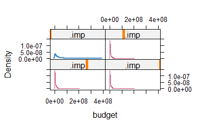

`r`r stripplot(imputations_cart, budget, col = c(, mdc(2)), pch = c(1, 20))

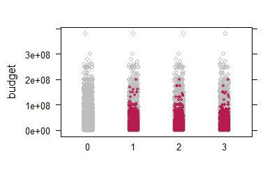

`r`r densityplot(imputations_cart, ~ vote_average | .imp)

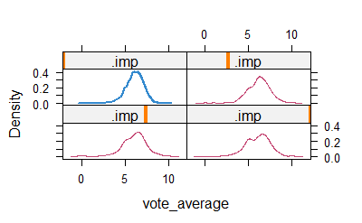

`r`r stripplot(imputations_cart, vote_average, col = c(, mdc(2)), pch = c(1, 20))

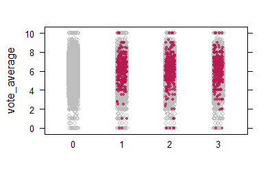

`r`r densityplot(imputations_cart, ~ vote_count | .imp)

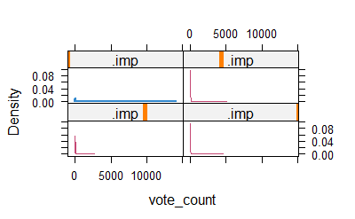

`r`r stripplot(imputations_cart, vote_count, col = c(, mdc(2)), pch = c(1, 20))

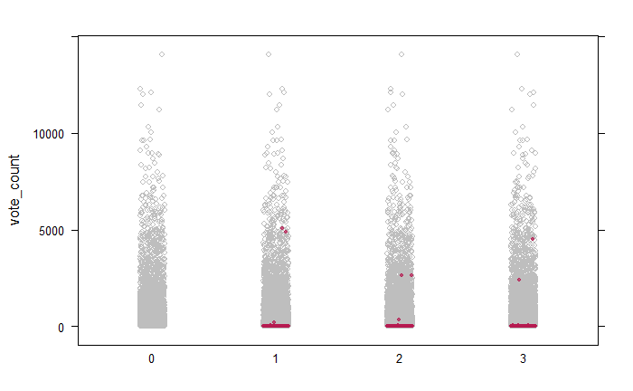

`r`r densityplot(imputations_cart, ~ meterScore | .imp)

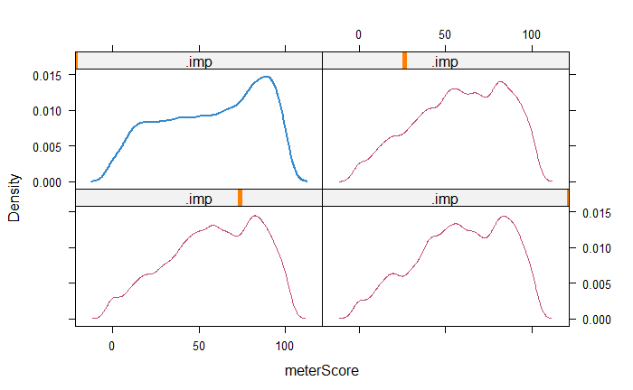

`r`r stripplot(imputations_cart, meterScore, col = c(, mdc(2)), pch = c(1, 20))

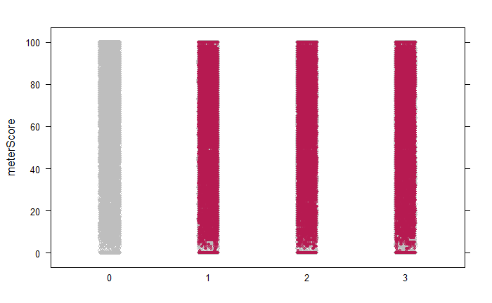

`r`r densityplot(imputations_cart, ~ meterClass | .imp)

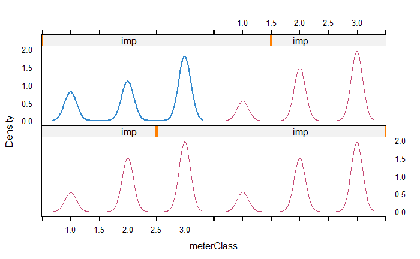

`r`r stripplot(imputations_cart, meterClass, col = c(, mdc(2)), pch = c(1, 20))

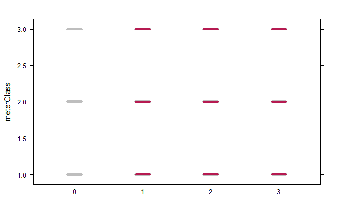

`r`r densityplot(imputations_cart, ~ num_spoken_languages | .imp)

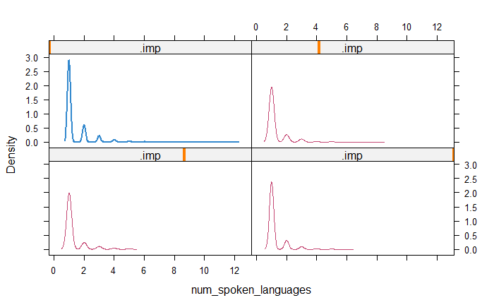

`r`r stripplot(imputations_cart, num_spoken_languages, col = c(, mdc(2)), pch = c(1, 20))

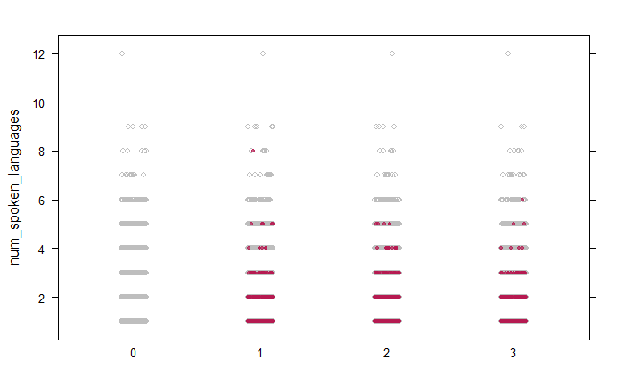

`r`r densityplot(imputations_cart, ~ number_of_cast | .imp)

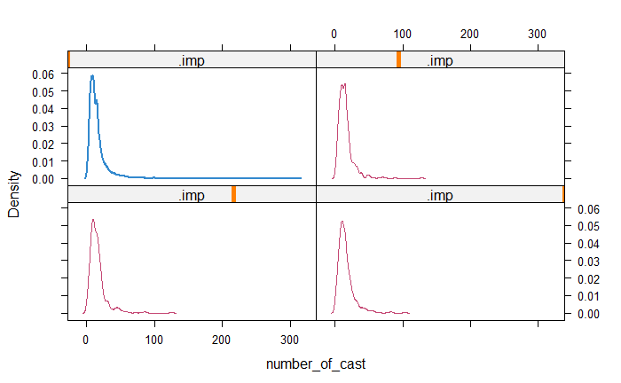

`r`r stripplot(imputations_cart, number_of_cast, col = c(, mdc(2)), pch = c(1, 20))

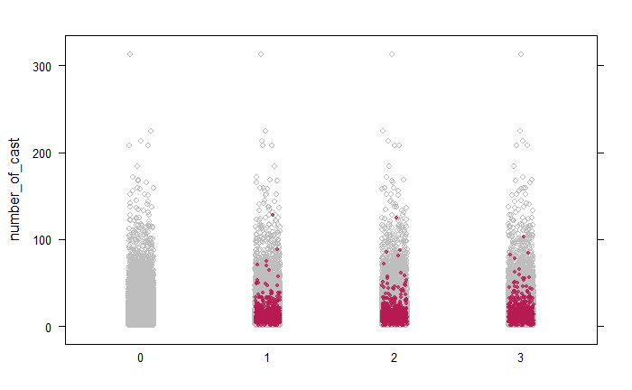

`r`r densityplot(imputations_cart, ~ female_cast | .imp)

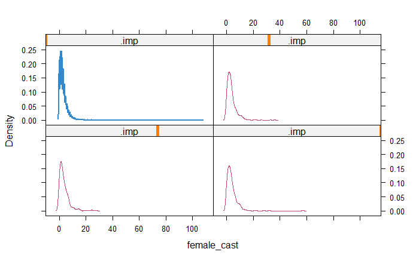

`r`r stripplot(imputations_cart, female_cast, col = c(, mdc(2)), pch = c(1, 20))

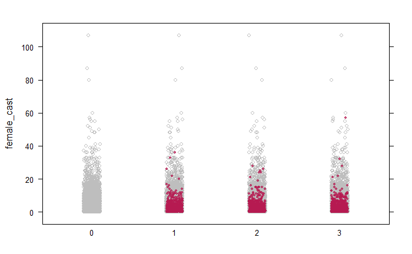

`r`r densityplot(imputations_cart, ~ male_cast | .imp)

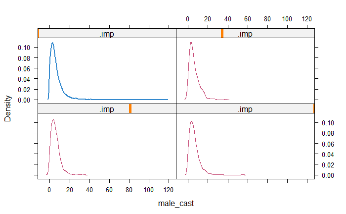

`r`r stripplot(imputations_cart, male_cast, col = c(, mdc(2)), pch = c(1, 20))

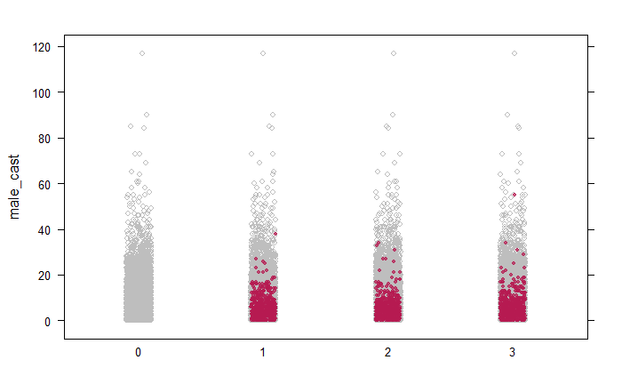

`r`r densityplot(imputations_cart, ~ unspecified_cast | .imp)

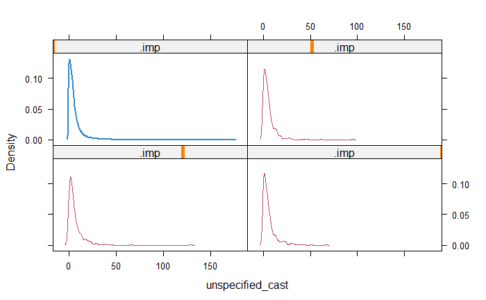

`r`r stripplot(imputations_cart, unspecified_cast, col = c(, mdc(2)), pch = c(1, 20))

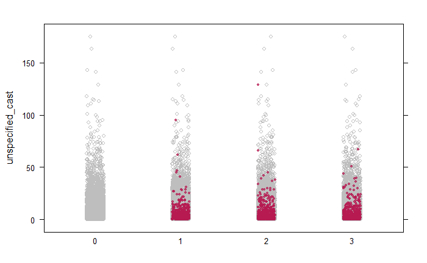

`r`r densityplot(imputations_cart, ~ number_of_crew | .imp)

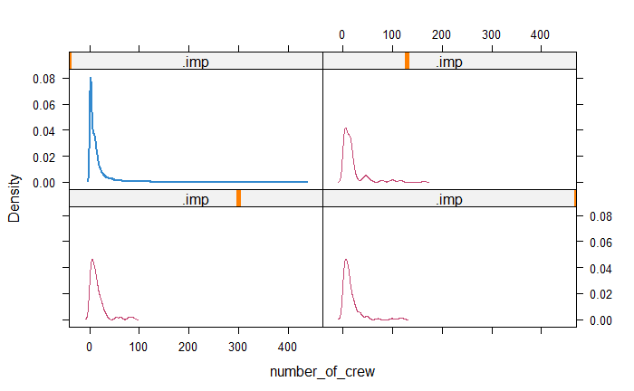

`r`r stripplot(imputations_cart, number_of_crew, col = c(, mdc(2)), pch = c(1, 20))

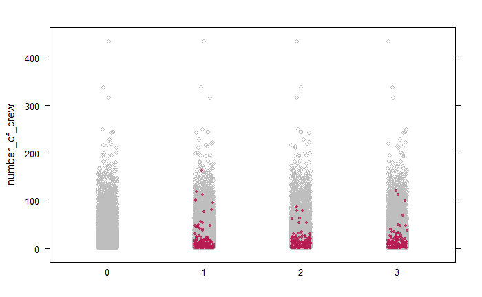

`r`r densityplot(imputations_cart, ~ female_crew | .imp)

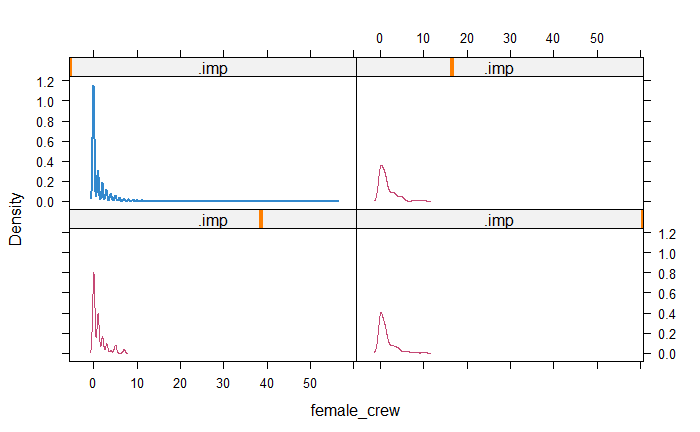

`r`r stripplot(imputations_cart, female_crew, col = c(, mdc(2)), pch = c(1, 20))